# R for Reproducible Scientific Analysis

5 April 2017

# Dataframe Manipulation with `dplyr`

Manipulation of dataframes means many things to many researchers, we often select certain observations (rows) or variables (columns), we often group the data by a certain variable(s), or we even calculate summary statistics. Subsetting data sets can be challenging in base R, because there is a fair bit of repetition. Repeating yourself will cost you time, both now and later, and potentially introduce some nasty bugs.

# Key Points

- Use the `dplyr` package to manipulate dataframes.
- Use `select()` to choose variables from a dataframe.
- Use `filter()` to choose data based on values.
- Use `group_by()` and `summarize()` to work with subsets of data.
- Use `mutate()` to create new variables.

# The `dplyr` package

The [`dplyr`](https://cran.r-project.org/web/packages/dplyr/dplyr.pdf) package provides a number of very useful functions for manipulating dataframes in a way that will reduce the above repetition, reduce the probability of making errors, and probably even save you some typing. As an added bonus, you might even find the `dplyr` grammar easier to read.

`dplyr` is part of the `tidyverse` package collection, so it should already be loaded. If you’ve started a new session, load the `tidyverse package:

```r
library("tidyverse")
```

# The pipe `%>%`

We often want to string together a series of `dplyr` functions. This is achieved using `dplyr`’s pipe operator, `%>%`. This takes the value on the left, and passes it as the first argument to the function call on the right.

`%>%` isn’t limited to `dplyr` functions. It’s an alternative way of writing any `R` code:

```r
rep("This is an example", times = 3)
```

```
## [1] "This is an example" "This is an example" "This is an example"
```

```r
"This is an example" %>% rep(times = 3)
```

```
## [1] "This is an example" "This is an example" "This is an example"
```

The shortcut to insert the pipe operator is `Ctrl`+`Shift`+`M` for Windows/Linux, and `Cmd`+`Shift`+`M` for Mac.

# Using `select()`

If, for example, we wanted to move forward with only a few of the variables in our dataframe we could use the `select()` function. This will keep only the variables you select.

```r
year_country_gdp <- select(gapminder, year, country, gdpPercap)
year_country_gdp
```

```
## # A tibble: 1,704 × 3
##     year     country gdpPercap
##    <int>       <chr>     <dbl>
## 1   1952 Afghanistan  779.4453
## 2   1957 Afghanistan  820.8530
## 3   1962 Afghanistan  853.1007
## 4   1967 Afghanistan  836.1971
## 5   1972 Afghanistan  739.9811
## 6   1977 Afghanistan  786.1134
## 7   1982 Afghanistan  978.0114
## 8   1987 Afghanistan  852.3959
## 9   1992 Afghanistan  649.3414
## 10  1997 Afghanistan  635.3414
## # ... with 1,694 more rows
```

If we open up `year_country_gdp` we’ll see that it only contains the `year`, `country` and `gdpPercap`. Above we used ‘normal’ grammar, but the strengths of `dplyr` lie in combining several functions using pipes. Since the pipes grammar is unlike anything we’ve seen in `R` before, let’s repeat what we’ve done above using pipes.

```r
year_country_gdp <- gapminder %>%
  select(year, country, gdpPercap)
year_country_gdp
```

```
## # A tibble: 1,704 × 3
##     year     country gdpPercap
##    <int>       <chr>     <dbl>
## 1   1952 Afghanistan  779.4453
## 2   1957 Afghanistan  820.8530
## 3   1962 Afghanistan  853.1007
## 4   1967 Afghanistan  836.1971
## 5   1972 Afghanistan  739.9811
## 6   1977 Afghanistan  786.1134
## 7   1982 Afghanistan  978.0114
## 8   1987 Afghanistan  852.3959
## 9   1992 Afghanistan  649.3414
## 10  1997 Afghanistan  635.3414
## # ... with 1,694 more rows
```

To help you understand why we wrote that in that way, let’s walk through it step by step. First we summon the `gapminder` dataframe and pass it on, using the pipe symbol (`%>%`), to the next step, which is the `select()` function. In this case we don’t specify which data object we use in the `select()` function since in gets that from the previous pipe. Fun fact: There is a good chance you have encountered pipes before in the shell. In `R`, a pipe symbol is `%>%` while in the shell it is `|` but the concept is the same!

# Using `filter()`

The `filter` function is a intuitive way of subsetting data. For example, we can look at the population per continent in 2002:

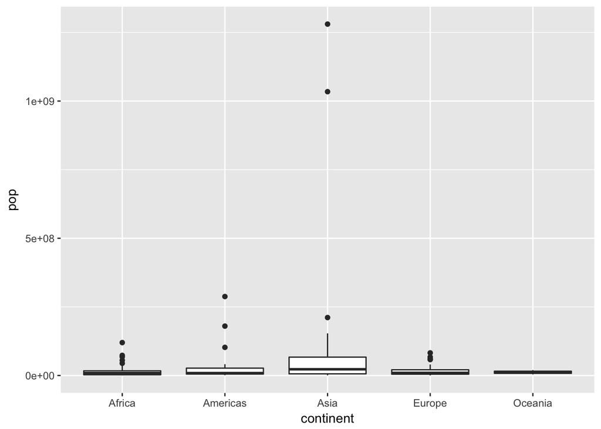

```r
gapminder %>%
  filter(year == 2002) %>%
  ggplot(mapping = aes(x = continent, y = pop)) +
  geom_boxplot()
```

If we now wanted to move forward with the above, but only with European countries, we can combine `select()` and `filter()`:

```r
year_country_gdp_euro <- gapminder %>%
  filter(continent == "Europe") %>%
  select(year, country, gdpPercap)
year_country_gdp_euro
```

```
## # A tibble: 360 × 3
##     year country gdpPercap
##    <int>   <chr>     <dbl>
## 1   1952 Albania  1601.056
## 2   1957 Albania  1942.284
## 3   1962 Albania  2312.889
## 4   1967 Albania  2760.197
## 5   1972 Albania  3313.422
## 6   1977 Albania  3533.004
## 7   1982 Albania  3630.881
## 8   1987 Albania  3738.933
## 9   1992 Albania  2497.438
## 10  1997 Albania  3193.055
## # ... with 350 more rows
```

## Challenge 1

Write a single command (which can span multiple lines and includes pipes) that will produce a dataframe that has the Norwegian values for `gdpPercap`, `lifeExp` and `year`, but not for other countries How many rows does your dataframe have and why?

```r
country_lifeExp_Norway <- gapminder %>%
  filter(country == "Norway") %>%
  select(year, lifeExp, gdpPercap)
country_lifeExp_Norway
```

```
## # A tibble: 12 × 3
##     year lifeExp gdpPercap
##    <int>   <dbl>     <dbl>
## 1   1952  72.670  10095.42
## 2   1957  73.440  11653.97
## 3   1962  73.470  13450.40
## 4   1967  74.080  16361.88
## 5   1972  74.340  18965.06
## 6   1977  75.370  23311.35
## 7   1982  75.970  26298.64
## 8   1987  75.890  31540.97
## 9   1992  77.320  33965.66
## 10  1997  78.320  41283.16
## 11  2002  79.050  44683.98
## 12  2007  80.196  49357.19
```

# Using `group_by()`

Now, we were supposed to be reducing the error prone repetitiveness of what can be done with base `R`, but up to now we haven’t done that since we would have to repeat the above for each continent. Instead of `filter()`, which will only pass observations that meet your criteria (in the above: `continent == "Europe"`), we can use `group_by()`, which will essentially use every unique criteria that you could have used in filter.

```r
gapminder
```

```
## # A tibble: 1,704 × 6
##        country  year      pop continent lifeExp gdpPercap
##          <chr> <int>    <dbl>     <chr>   <dbl>     <dbl>
## 1  Afghanistan  1952  8425333      Asia  28.801  779.4453
## 2  Afghanistan  1957  9240934      Asia  30.332  820.8530
## 3  Afghanistan  1962 10267083      Asia  31.997  853.1007
## 4  Afghanistan  1967 11537966      Asia  34.020  836.1971
## 5  Afghanistan  1972 13079460      Asia  36.088  739.9811
## 6  Afghanistan  1977 14880372      Asia  38.438  786.1134
## 7  Afghanistan  1982 12881816      Asia  39.854  978.0114
## 8  Afghanistan  1987 13867957      Asia  40.822  852.3959
## 9  Afghanistan  1992 16317921      Asia  41.674  649.3414
## 10 Afghanistan  1997 22227415      Asia  41.763  635.3414
## # ... with 1,694 more rows
```

```r
gapminder %>%
  group_by(continent)
```

```
## Source: local data frame [1,704 x 6]
## Groups: continent [5]
##
##        country  year      pop continent lifeExp gdpPercap
##          <chr> <int>    <dbl>     <chr>   <dbl>     <dbl>
## 1  Afghanistan  1952  8425333      Asia  28.801  779.4453
## 2  Afghanistan  1957  9240934      Asia  30.332  820.8530
## 3  Afghanistan  1962 10267083      Asia  31.997  853.1007
## 4  Afghanistan  1967 11537966      Asia  34.020  836.1971
## 5  Afghanistan  1972 13079460      Asia  36.088  739.9811
## 6  Afghanistan  1977 14880372      Asia  38.438  786.1134
## 7  Afghanistan  1982 12881816      Asia  39.854  978.0114
## 8  Afghanistan  1987 13867957      Asia  40.822  852.3959
## 9  Afghanistan  1992 16317921      Asia  41.674  649.3414
## 10 Afghanistan  1997 22227415      Asia  41.763  635.3414
## # ... with 1,694 more rows
```

# Using `summarize()`

The above was a bit on the uneventful side because `group_by()` much more exciting in conjunction with `summarize()`. This will allow use to create new variable(s) by using functions that repeat for each of the continent-specific data frames. That is to say, using the `group_by()` function, we split our original dataframe into multiple pieces, then we can run functions (e.g. `mean()` or `sd()`) within `summarize()`.

```r
gapminder %>%
  group_by(continent) %>%
  summarize(mean_gdpPercap = mean(gdpPercap))
```

```
## # A tibble: 5 × 2
##   continent mean_gdpPercap
##       <chr>          <dbl>
## 1    Africa       2193.755
## 2  Americas       7136.110
## 3      Asia       7902.150
## 4    Europe      14469.476
## 5   Oceania      18621.609
```

We can also use a pipe to directly “feed” our processed data into `ggplot2`:

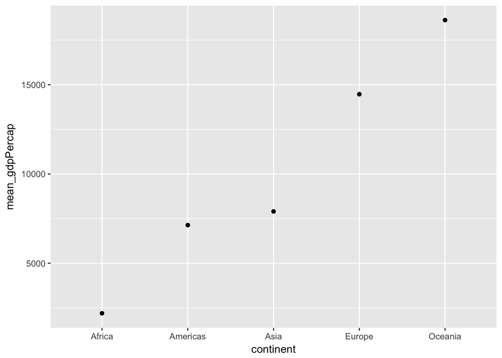

```r
gapminder %>%
  group_by(continent) %>%
  summarize(mean_gdpPercap = mean(gdpPercap)) %>%
  ggplot(mapping = aes(x = continent, y = mean_gdpPercap)) +
  geom_point()
```

That allowed us to calculate the mean `gdpPercap` for each continent, but it gets even better.

## Challenge 2

Calculate the average life expectancy per country in Asia. Which has the longest average life expectancy and which has the shortest average life expectancy?

```r
gapminder %>%
  filter(continent == "Asia") %>%
  group_by(country) %>%
  summarize(mean_lifeExp = mean(lifeExp)) %>%
  filter(mean_lifeExp == min(mean_lifeExp) | mean_lifeExp == max(mean_lifeExp))
```

```
## # A tibble: 2 × 2
##       country mean_lifeExp
##         <chr>        <dbl>
## 1 Afghanistan     37.47883
## 2       Japan     74.82692
```

The function `group_by()` allows us to group by multiple variables. Let’s group by year and continent.

```r
gapminder %>%
  group_by(continent, year) %>%
  summarize(mean_gdpPercap = mean(gdpPercap))
```

```
## Source: local data frame [60 x 3]
## Groups: continent [?]
##
##    continent  year mean_gdpPercap
##        <chr> <int>          <dbl>
## 1     Africa  1952       1252.572
## 2     Africa  1957       1385.236
## 3     Africa  1962       1598.079
## 4     Africa  1967       2050.364
## 5     Africa  1972       2339.616
## 6     Africa  1977       2585.939
## 7     Africa  1982       2481.593
## 8     Africa  1987       2282.669
## 9     Africa  1992       2281.810
## 10    Africa  1997       2378.760
## # ... with 50 more rows
```

That is already quite powerful, but it gets even better! You’re not limited to defining one new variable in `summarize()`.

```r
gapminder %>%
  group_by(continent, year) %>%
  summarize(mean_gdpPercap = mean(gdpPercap),
            sd_gdpPercap = sd(gdpPercap),
            mean_pop = mean(pop),
            sd_pop = sd(pop))
```

```
## Source: local data frame [60 x 6]
## Groups: continent [?]
##
##    continent  year mean_gdpPercap sd_gdpPercap mean_pop   sd_pop
##        <chr> <int>          <dbl>        <dbl>    <dbl>    <dbl>
## 1     Africa  1952       1252.572     982.9521  4570010  6317450
## 2     Africa  1957       1385.236    1134.5089  5093033  7076042
## 3     Africa  1962       1598.079    1461.8392  5702247  7957545
## 4     Africa  1967       2050.364    2847.7176  6447875  8985505
## 5     Africa  1972       2339.616    3286.8539  7305376 10130833
## 6     Africa  1977       2585.939    4142.3987  8328097 11585184
## 7     Africa  1982       2481.593    3242.6328  9602857 13456243
## 8     Africa  1987       2282.669    2566.5319 11054502 15277484
## 9     Africa  1992       2281.810    2644.0756 12674645 17562719
## 10    Africa  1997       2378.760    2820.7281 14304480 19873013
## # ... with 50 more rows
```

# Using `mutate()`

We can also create new variables prior to (or even after) summarizing information using `mutate()`.

```r
gapminder %>%
  mutate(gdp_billion = gdpPercap * pop / 10^9)
```

```
## # A tibble: 1,704 × 7
##        country  year      pop continent lifeExp gdpPercap gdp_billion
##          <chr> <int>    <dbl>     <chr>   <dbl>     <dbl>       <dbl>
## 1  Afghanistan  1952  8425333      Asia  28.801  779.4453    6.567086
## 2  Afghanistan  1957  9240934      Asia  30.332  820.8530    7.585449
## 3  Afghanistan  1962 10267083      Asia  31.997  853.1007    8.758856
## 4  Afghanistan  1967 11537966      Asia  34.020  836.1971    9.648014
## 5  Afghanistan  1972 13079460      Asia  36.088  739.9811    9.678553
## 6  Afghanistan  1977 14880372      Asia  38.438  786.1134   11.697659
## 7  Afghanistan  1982 12881816      Asia  39.854  978.0114   12.598563
## 8  Afghanistan  1987 13867957      Asia  40.822  852.3959   11.820990
## 9  Afghanistan  1992 16317921      Asia  41.674  649.3414   10.595902
## 10 Afghanistan  1997 22227415      Asia  41.763  635.3414   14.121996
## # ... with 1,694 more rows
```

```r
gapminder %>%
  mutate(gdp_billion = gdpPercap * pop / 10^9) %>%
  group_by(continent, year) %>%
  summarize(mean_gdpPercap = mean(gdpPercap),
            sd_gdpPercap = sd(gdpPercap),
            mean_pop = mean(pop),
            sd_pop = sd(pop),
            mean_gdp_billion = mean(gdp_billion),
            sd_gdp_billion = sd(gdp_billion))
```

```
## Source: local data frame [60 x 8]
## Groups: continent [?]
##
##    continent  year mean_gdpPercap sd_gdpPercap mean_pop   sd_pop
##        <chr> <int>          <dbl>        <dbl>    <dbl>    <dbl>
## 1     Africa  1952       1252.572     982.9521  4570010  6317450
## 2     Africa  1957       1385.236    1134.5089  5093033  7076042
## 3     Africa  1962       1598.079    1461.8392  5702247  7957545
## 4     Africa  1967       2050.364    2847.7176  6447875  8985505
## 5     Africa  1972       2339.616    3286.8539  7305376 10130833
## 6     Africa  1977       2585.939    4142.3987  8328097 11585184
## 7     Africa  1982       2481.593    3242.6328  9602857 13456243
## 8     Africa  1987       2282.669    2566.5319 11054502 15277484
## 9     Africa  1992       2281.810    2644.0756 12674645 17562719
## 10    Africa  1997       2378.760    2820.7281 14304480 19873013
## # ... with 50 more rows, and 2 more variables: mean_gdp_billion <dbl>,
## #   sd_gdp_billion <dbl>
```

## Challenge 3

Calculate the average life expectancy and GDP in 1987 for each continent.

```r
gapminder %>%
  mutate(gdp_billion = gdpPercap * pop / 10^9) %>%
  filter(year == 1987) %>%
  group_by(continent) %>%
  summarize(mean_lifeExp = mean(lifeExp),
            mean_gdp_billion = mean(gdp_billion))
```

```
## # A tibble: 5 × 3
##   continent mean_lifeExp mean_gdp_billion
##       <chr>        <dbl>            <dbl>
## 1    Africa     53.34479         24.10726
## 2  Americas     68.09072        439.44779
## 3      Asia     64.85118        241.78476
## 4    Europe     73.64217        316.50747
## 5   Oceania     75.32000        209.45156
```

# Using `dplyr` and `ggplot2` to visualize average global life expectancy

We will now demonstrate how to use functions from both `dplyr`and `ggplot2` to visualize the average life expectancy of countries that are part of the `gapminder` data set.

First, we need to calculate the average life expectancy for each country using the `summarize()` function:

```r
gapminder_country_summary <- gapminder %>%
  group_by(country) %>%
  summarize(mean_lifeExp = mean(lifeExp))
gapminder_country_summary
```

```
## # A tibble: 142 × 2
##        country mean_lifeExp
##          <chr>        <dbl>
## 1  Afghanistan     37.47883
## 2      Albania     68.43292
## 3      Algeria     59.03017
## 4       Angola     37.88350
## 5    Argentina     69.06042
## 6    Australia     74.66292
## 7      Austria     73.10325
## 8      Bahrain     65.60567
## 9   Bangladesh     49.83408
## 10     Belgium     73.64175
## # ... with 132 more rows
```

Next, we use a database for mapping coordinates (`install.packages("maps")`) to align with the average life expectancy data from above. We can directly use the output and pipe it into `ggplot()`!

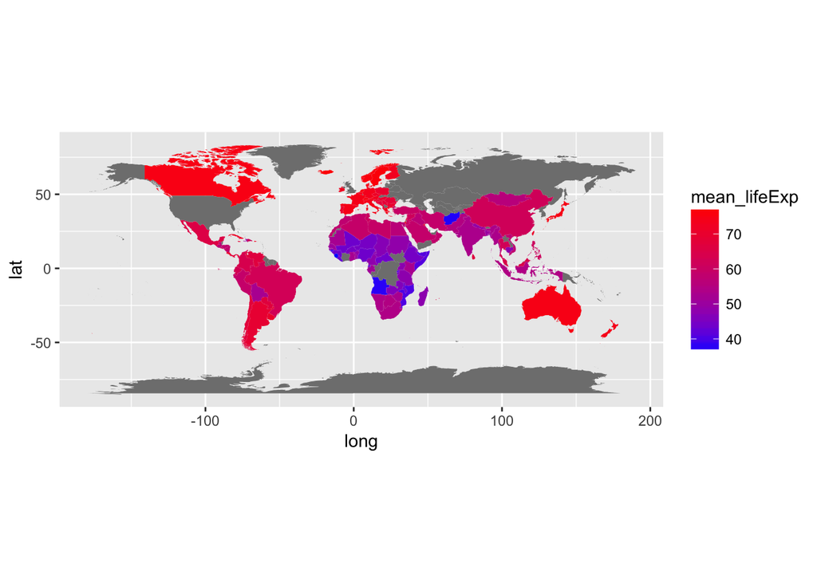

```r
map_data("world") %>%
  rename(country = region) %>%
  left_join(gapminder_country_summary, by = "country") %>%
  ggplot() +
  geom_polygon(aes(x = long, y = lat, group = group, fill = mean_lifeExp)) +
  scale_fill_gradient(low = "blue", high = "red") +
  coord_equal()
```

Note that “grey” countries are not part of `gapminder` or appear under a different name and hence only appear as `NA`’s.

# Key Points

- Use the `dplyr` package to manipulate dataframes.
- Use `select()` to choose variables from a dataframe.
- Use `filter()` to choose data based on values.
- Use `group_by()` and `summarize()` to work with subsets of data.
- Use `mutate()` to create new variables.